# Vision Transformers

The Vision Transformer (ViT) brings the power of transformers, which have excelled in text generation tasks like T5, to the field of image analysis. In text-based transformers like T5, the model processes sequences of words or tokens, learning contextual relationships to generate coherent text. Vision Transformers work similarly, but instead of text tokens, they use image patches as input tokens.

In ViT, an image is divided into small, fixed-size patches, each of which is flattened into a sequence, similar to how words are arranged in text transformers. These patches are then embedded and fed into the transformer model. Using self-attention, the ViT learns to focus on different parts of the image simultaneously, capturing both local and global visual patterns. The model can then use these patterns to classify images, detect objects, or perform other vision tasks.

During training, ViTs are typically pre-trained on large image datasets to learn general features, then fine-tuned on specific tasks for better performance. This two-step training process is similar to language models and helps the model adapt to new visual tasks while retaining strong foundational image representations.

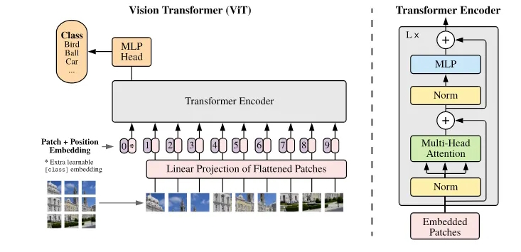

ViT.jpg

# Image Inpainting (Infilling) using ImageGPT

Image infilling is the process of reconstructing missing or damaged parts of an image by predicting and generating the appropriate content to seamlessly fill the gaps. ImageGPT, an adaptation of the GPT (Generative Pre-trained Transformer) architecture for visual data, effectively performs image infilling by treating images as sequences of pixels or patches, similar to how text is processed in language models.

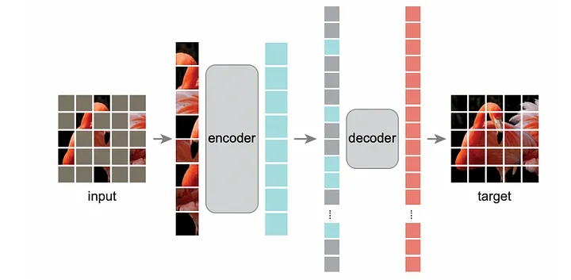

infilling.jpg

An overview of the ImageGPT approach: First, we preprocess raw images by resizing them to a **low resolution** and reshaping them into a **1D sequence**. We then select one of two pre-training objectives: autoregressive next-pixel prediction or masked pixel prediction. The representations learned from these objectives can be further utilized for other tasks, such as image classification, using either linear probes or fine-tuning. ([Paper](https://cdn.openai.com/papers/Generative_Pretraining_from_Pixels_V2.pdf))

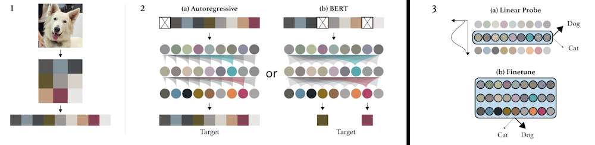

imagegpt.jpg

## Setting-up environment

We first install HuggingFace Transformers.

```python
!pip install -q git+https://github.com/huggingface/transformers.git
```

```
  Installing build dependencies ... done
  Getting requirements to build wheel ... done
  Preparing metadata (pyproject.toml) ... done
```

## Unconditional image generation

In this section, we aim to generate a few images using ImageGPT by providing the model with some random initial inputs.

We start by initializing the feature extractor and the model, then move the model to the GPU for faster processing.

```python
from transformers import ImageGPTFeatureExtractor, ImageGPTForCausalImageModeling
import numpy as np
import torch

feature_extractor = ImageGPTFeatureExtractor.from_pretrained('openai/imagegpt-medium')
model = ImageGPTForCausalImageModeling.from_pretrained('openai/imagegpt-medium')

device = torch.device("cuda" if torch.cuda.is_available() else "cpu")

model.to(device);
```

Here we only feed the start of sequence (SOS) special token to the model, and let it generate 32x32 = 1024 pixel values using the `generate()` method. Each pixel value is one of 512 possible color clusters.

```python
# unconditional generation of 8 images
batch_size = 8
context = torch.full((batch_size, 1), model.config.vocab_size - 1) #initialize with SOS token (with ID 512)
context = torch.tensor(context).to(device)
output = model.generate(input_ids=context, max_length=model.config.n_positions + 1, temperature=1.0, do_sample=True, top_k=40)
```

[output not shown]

```python
#visualize samples with Image-GPT color palette.
%matplotlib inline
import matplotlib.pyplot as plt
import numpy as np

clusters = feature_extractor.clusters
n_px = feature_extractor.size

samples = output[:,1:].cpu().detach().numpy()
samples_img = [np.reshape(np.rint(127.5 * (clusters[s] + 1.0)), [32, 32, 3]).astype(np.uint8) for s in samples] # convert color cluster tokens back to pixels
f, axes = plt.subplots(1, batch_size, dpi=300)

for img, ax in zip(samples_img, axes):
    ax.axis('off')
    ax.imshow(img)
```

[figure not shown]

# Tokenize Cropped Images for Image Completion

Given the upper half of an image, it’s intriguing to see how ImageGPT will complete it.

Let’s generate 8 possible completions for a given image. To do this, we’ll create 8 copies of the image as starting points.

```python
import requests
from PIL import Image

url = 'https://assetsnffrgf-a.akamaihd.net/assets/m/502013285/univ/art/502013285_univ_sqr_xl.jpg'
url = "https://avatars.githubusercontent.com/u/326577?v=4"
image = Image.open(requests.get(url, stream=True).raw).convert("RGB")
image
```

[figure not shown]

We prepare the images using ImageGPTFeatureExtractor, which will resize each image to 32x32x3, normalize it and then apply color clustering. Finally, it will flatten the pixel values out to a long list of 32x32 = 1024 values.

```python
encoding = feature_extractor([image for _ in range(8)], return_tensors="pt")
print(encoding.keys())
```

```
dict_keys(['input_ids'])
```

```python
encoding.input_ids.shape
```

```
torch.Size([8, 1024])
```

Next, we only keep the first 512 tokens (pixel values).

```python
samples = encoding.input_ids.numpy()
n_px_crop = 16
# crop top n_px_crop rows. These will be the conditioning tokens
primers = samples[:,:n_px_crop*n_px['height']]
```

```python
print(primers.shape)
```

```
(8, 512)
```

We can visualize both the original (lower-resolution and color-clustered) images and the cropped ones:

```python
#visualize samples and crops with Image-GPT color palette. Should look similar to original resized images
samples_img = [np.reshape(np.rint(127.5 * (clusters[s] + 1.0)), [n_px['height'], n_px['width'], 3]).astype(np.uint8) for s in samples] # convert color clusters back to pixels
primers_img = [np.reshape(np.rint(127.5 * (clusters[s] + 1.0)), [n_px_crop,n_px['width'], 3]).astype(np.uint8) for s in primers] # convert color clusters back to pixels

f, axes = plt.subplots(1, batch_size, dpi=300)
for img,ax in zip(samples_img, axes):
    ax.axis('off')
    ax.imshow(img)

f, axes2 = plt.subplots(1, batch_size, dpi=300)
for img,ax in zip(primers_img, axes2):
    ax.axis('off')
    ax.imshow(img)
```

[figure not shown]

# Conditional Image Completion

Let’s let ImageGPT complete the rest! For this, we also add the start token. Note that we can leverage all possibilities of HuggingFace’s generate() method, which are explained in detail in [this blog post](https://huggingface.co/blog/how-to-generate).

```python
context = np.concatenate((np.full((batch_size, 1), model.config.vocab_size - 1), primers), axis=1)
context = torch.tensor(context).to(device)
output = model.generate(input_ids=context, max_length=n_px['height']*n_px['width'] + 1, temperature=1.0, do_sample=True, top_k=40)
```

```python
#visualize samples with Image-GPT color palette.
samples = output[:,1:].cpu().detach().numpy()
samples_img = [np.reshape(np.rint(127.5 * (clusters[s] + 1.0)), [n_px['height'], n_px['width'], 3]).astype(np.uint8) for s in samples] # convert color cluster tokens back to pixels
f, axes = plt.subplots(1, batch_size, dpi=300)

for img,ax in zip(samples_img, axes):
    ax.axis('off')
    ax.imshow(img)
```

[figure not shown]